[figure not shown]

# **Predicting Fatality of Terrorist Attacks**

### **Cailin O'Toole, Bethany Hsiao**

## **Introduction**

Thousands die every year from terrorist attacks and millions more have their lives affected by terrorism. It is incredibly important to understand what makes a terrorist attack deadly so we can work to mitigate this risk as a global community. In this tutorial we will attempt to discern trends in terrorist attacks to determine the variables that make the attack likely to cause fatalities. This data can be used to decide which regions need the most assistance fighting terrorism and which types of attacks more resources should go towards preventing.The Global Terrorism Database (GTD) contains data on over 100,000 terrorist attacks, collected by the START center in partnership with the University of Maryland. This data will allow us to predict which attacks will be deadly.

The GTD chooses to include terrorist events as terrorist attacks if they meet two of three criteria.

> 1) The attack is “aimed at attaining a political, economic, religious, or social goal” (GTD)and is not done exclusively for profit.

> 2) The attack is attempting to “coerce, intimidate, or convey some other message to a larger audience” (GTD) beyond just the attack victims.

> 3) The attack is not a part of “legitimate warfare activities” (GTD) because it targets noncombatants.

It must be noted that the GTD does not account for cyberattacks because the complexity that including these types of attacks would require, however GTD along with start is working to develop the ability to track cyber attacks. To learn more about the Global Terrorism Database team and the mission of the National Consortium for the Study of Terrorism and Responses to Terrorism (START) visit their [webpage](https://www.start.umd.edu/).

## **Data Collection**

We will use the pandas python libraries to work with our data. Click [here](https://pandas.pydata.org/pandas-docs/stable/install.html) for more information on installing these libraries and [here](https://docs.python.org/3/) for python documentation.

> The Data Lifecycle (https://www.usgs.gov/products/data-and-tools/data-management/data-lifecycle) begins at data collection (or data acquisition). For this we will be using the GTD dataset, which can be imported here (https://www.start.umd.edu/gtd/access/) as a csv file. We will read these csv files into a DataFrame, which allows us to visualize data as a matrix with rows and columns. We can manipulate this matrix by iterating through the rows and columns or by deleting or combining rows and columns.

> Although the GTD has data on terrorist attacks going back to the 1970s, we will choose only to look at a smaller subset of data. Technological improvements and the growth of the internet has greatly improved collection techniques. The GTD warns that data may appear to show differences in attack level between 1998, 2008, and 2012 because of changes in data collection methodology. In order to work with a more standardized data set we will only look at data since 2012. 2012 marks the date that data collection for the GTD was moved to the University of Maryland. To read more about the GTD dataset click [here](https://www.start.umd.edu/gtd/about/).

```python
import pandas as pd
import matplotlib.pyplot as plt
data = pd.read_csv("globalterrorismdb_0919dist.csv")
```

```
/opt/conda/lib/python3.7/site-packages/IPython/core/interactiveshell.py:3058: DtypeWarning: Columns (61,63,79,114,115) have mixed types. Specify dtype option on import or set low_memory=False.
  interactivity=interactivity, compiler=compiler, result=result)
```

## **Tidying and Modifying the Data**

To clean the data and focus only on variables that might affect the fatality of an attack, we removed many columns from the database. Some columns like attackType and weaptype2 were removed because they track the presence of a secondary mode of attack or secondary weapon and most of these variables are left empty because there was only a single type of weapon or mode of attack in the terrorist incident. We felt other columns like resolution, which is the date an extended incident was resolved, did not have a strong bearing on whether or not there were fatalities in an attack. Finally we removed several columns like provstate or addnotes because they contained unique comments for each attack that were unrepeated.

- Event ID
- Year
- Month
- Extended: categorical variable, whether or not an event lasted 24 hours or more
- Country Code
- Country
- Region Code
- Region
- Latitude
- Longitude
- Criteria1: categorical variable, whether the attack satisfies criteria 1 above
- Criteria2: categorical variable, whether the attack satisfies criteria 2 above
- Criteria3: categorical variable, whether the attack satisfies criteria 3 above
- MultipleAttacks: categorical variable, whether an attack is part of a multiple incident
- Success: categorical variable, whether or not the attack achieved its goal
- Suicide
- AttackTypeCode: categorical variable, what general method of attack was used
- Attack Type
- TargetTypeCode: categorical variable, the general type of target attacked
- targsubtype1: categorical variable, gives more specific types of target
- targsubtype1_txt
- TargetNationalityCode: categorical variable, the nationality of the target attacked
- TargetNationality
- Individual: categorical variable, if the perpetrator has no affiliation with any terrorist groups
- NumberAttackers: numeric variable, the number of perpetrators
- WeaponTypeCode: categorical variable, the type of weapon used in the attack
- WeaponType
- NumberKilled: numerical variable, number of victims killed
- Number Wounded: numerical variable, number of victims wounded
- Property: categorical variable, whether any property was damaged in the attack
- HostageKidnapping: categorical variable, whether attackers took hostages
- Killed: categorical variable, whether or not there were fatalities

First, we are going to modify the nkill variable to turn it from a numerical variable to a new categorical variable called Killed denoting whether or not there were fatalities. If the value of nkill is 0 we will enter 0 in Killed, but if the value of nkill is any other number we will place a 1 in killed. This will allow us to perform machine learning.

Many of the columns contain values like unknown or -99 to indicate uncertainty or lack of information. Because these incidents are not properly reported we will remove them from our dataset.

Finally, we used the `dropna()` function which is part of the [pandas](https://pandas.pydata.org/pandas-docs/stable/reference/api/pandas.DataFrame.dropna.html) library. The `dropna()` function drops any NA values. There are many empty values in the GTD dataset and when transforming the csv files into the pandas dataset they are automatically transformed into an NA, so dropna will remove any incomplete lines for us.

```python
df = data[["eventid", "iyear", "imonth", "extended", "country", "country_txt", "region", "region_txt", "latitude", "longitude", "crit1", "crit2", "crit3", "multiple", "success", "suicide", "attacktype1", "attacktype1_txt", "targtype1", "targtype1_txt", "targsubtype1", "targsubtype1_txt", "natlty1", "natlty1_txt", "individual", "nperps", "weaptype1", "weaptype1_txt", "nkill", "nwound", "property", "ishostkid"]]
df = df[df.nperps != -99]
df = df[df.property != -9]
df = df[df.ishostkid != -9]
df = df.dropna()

df = df.astype({"nkill": int, "nwound": int})
df = df.astype({"latitude": float, "longitude": float})
df = df.rename(columns={"eventid": "EventID", "iyear": "Year", "imonth": "Month", "extended": "Extended", "country": "CountryCode", "country_txt": "Country", "region": "RegionCode", "region_txt": "Region", "latitude": "Latitude", "longitude": "Longitude", "crit1": "Criteria1", "crit2": "Criteria2", "crit3": "Criteria3", "multiple": "MultipleAttacks", "success": "Success", "suicide": "Suicide", "attacktype1": "AttackTypeCode", "attacktype1_txt": "AttackType", "targtype1": "TargetTypeCode", "targtype1_txt": "TargetType", "natlty1": "TargetNationalityCode", "natlty1_txt": "TargetNationality", "individual": "Individual", "nperps": "NumberAttackers", "weaptype1": "WeaponTypeCode", "weaptype1_txt": "WeaponType", "nkill": "NumberKilled", "nwound": "NumberWounded", "property": "PropertyDamage", "ishostkid":"HostageKidnapping"})
```

```python
for index, row in df.iterrows():
  if row['NumberKilled'] > 0:
    df.at[index, 'Killed'] = 1
  else:
    df.at[index, 'Killed'] = 0
df = df.astype({"Killed": int})
df
```

|  | EventID | Year | Month | Extended | CountryCode | Country | RegionCode | Region | Latitude | Longitude | ... | TargetNationality | Individual | NumberAttackers | WeaponTypeCode | WeaponType | NumberKilled | NumberWounded | PropertyDamage | HostageKidnapping | Killed |
| --- | --- | --- | --- | --- | --- | --- | --- | --- | --- | --- | --- | --- | --- | --- | --- | --- | --- | --- | --- | --- | --- |
| 16 | 201201010020 | 2012 | 1 | 0 | 217 | United States | 1 | North America | 30.488927 | -87.227633 | ... | United States | 1 | 1 | 8 | Incendiary | 0 | 0 | 1 | 0 | 0 |
| 18 | 201201020002 | 2012 | 1 | 0 | 153 | Pakistan | 6 | South Asia | 25.416302 | 68.286725 | ... | Pakistan | 0 | 2 | 5 | Firearms | 1 | 1 | 1 | 0 | 1 |
| 19 | 201201020003 | 2012 | 1 | 0 | 153 | Pakistan | 6 | South Asia | 24.891116 | 67.143312 | ... | Pakistan | 0 | 2 | 6 | Explosives | 0 | 4 | 1 | 0 | 0 |
| 20 | 201201020005 | 2012 | 1 | 0 | 4 | Afghanistan | 6 | South Asia | 31.379885 | 64.299440 | ... | International | 0 | 2 | 6 | Explosives | 0 | 0 | 0 | 0 | 0 |
| 26 | 201201020012 | 2012 | 1 | 0 | 4 | Afghanistan | 6 | South Asia | 35.585669 | 63.328089 | ... | Afghanistan | 0 | 2 | 6 | Explosives | 2 | 0 | 0 | 0 | 1 |
| 27 | 201201020014 | 2012 | 1 | 0 | 174 | Senegal | 11 | Sub-Saharan Africa | 12.654455 | -16.362767 | ... | Senegal | 0 | 15 | 5 | Firearms | 1 | 6 | 1 | 0 | 1 |
| 41 | 201201030005 | 2012 | 1 | 0 | 147 | Nigeria | 11 | Sub-Saharan Africa | 12.786790 | 10.237710 | ... | Nigeria | 0 | 15 | 6 | Explosives | 1 | 1 | 1 | 0 | 1 |
| 44 | 201201030008 | 2012 | 1 | 0 | 4 | Afghanistan | 6 | South Asia | 31.631083 | 65.742227 | ... | Afghanistan | 0 | 1 | 6 | Explosives | 7 | 16 | 1 | 0 | 1 |
| 45 | 201201030009 | 2012 | 1 | 0 | 4 | Afghanistan | 6 | South Asia | 31.631083 | 65.742227 | ... | Afghanistan | 0 | 1 | 6 | Explosives | 8 | 19 | 1 | 0 | 1 |
| 67 | 201201030035 | 2012 | 1 | 0 | 160 | Philippines | 5 | Southeast Asia | 9.053611 | 125.586667 | ... | Philippines | 0 | 50 | 6 | Explosives | 1 | 2 | 0 | 0 | 1 |
| 74 | 201201030043 | 2012 | 1 | 0 | 167 | Russia | 9 | Eastern Europe | 43.320228 | 45.654493 | ... | Russia | 0 | 2 | 6 | Explosives | 0 | 0 | 0 | 0 | 0 |
| 76 | 201201030045 | 2012 | 1 | 0 | 147 | Nigeria | 11 | Sub-Saharan Africa | 10.286652 | 11.163862 | ... | Nigeria | 0 | 7 | 6 | Explosives | 0 | 11 | 1 | 0 | 0 |
| 80 | 201201030052 | 2012 | 1 | 0 | 217 | United States | 1 | North America | 40.946748 | -74.073503 | ... | United States | 1 | 1 | 8 | Incendiary | 0 | 0 | 1 | 0 | 0 |
| 87 | 201201040010 | 2012 | 1 | 0 | 228 | Yemen | 10 | Middle East & North Africa | 12.849085 | 45.037275 | ... | Yemen | 0 | 5 | 5 | Firearms | 2 | 13 | 1 | 0 | 1 |
| 111 | 201201050004 | 2012 | 1 | 0 | 95 | Iraq | 10 | Middle East & North Africa | 31.135535 | 45.861207 | ... | Iraq | 0 | 1 | 6 | Explosives | 45 | 70 | 0 | 0 | 1 |
| 117 | 201201050011 | 2012 | 1 | 0 | 153 | Pakistan | 6 | South Asia | 24.891116 | 67.143312 | ... | Pakistan | 0 | 4 | 5 | Firearms | 2 | 1 | 1 | 0 | 1 |
| 118 | 201201050012 | 2012 | 1 | 0 | 153 | Pakistan | 6 | South Asia | 24.891116 | 67.143312 | ... | Pakistan | 0 | 2 | 5 | Firearms | 2 | 0 | 1 | 0 | 1 |
| 122 | 201201050016 | 2012 | 1 | 0 | 93 | Indonesia | 5 | Southeast Asia | 5.559298 | 95.326815 | ... | Indonesia | 0 | 1 | 5 | Firearms | 3 | 0 | 0 | 0 | 1 |
| 127 | 201201050022 | 2012 | 1 | 0 | 160 | Philippines | 5 | Southeast Asia | 6.116219 | 125.169392 | ... | Philippines | 0 | 2 | 5 | Firearms | 1 | 1 | 1 | 0 | 1 |
| 134 | 201201060005 | 2012 | 1 | 0 | 205 | Thailand | 5 | Southeast Asia | 6.391460 | 101.517299 | ... | Thailand | 0 | 30 | 5 | Firearms | 2 | 3 | 1 | 0 | 1 |
| 157 | 201201060031 | 2012 | 1 | 0 | 147 | Nigeria | 11 | Sub-Saharan Africa | 11.840793 | 13.141391 | ... | Nigeria | 0 | 3 | 5 | Firearms | 2 | 0 | 1 | 0 | 1 |
| 163 | 201201060038 | 2012 | 1 | 0 | 4 | Afghanistan | 6 | South Asia | 34.107510 | 64.305726 | ... | Afghanistan | 0 | 1 | 5 | Firearms | 3 | 0 | 1 | 0 | 1 |
| 170 | 201201070008 | 2012 | 1 | 0 | 92 | India | 6 | South Asia | 34.288890 | 74.463713 | ... | India | 0 | 6 | 6 | Explosives | 1 | 0 | 1 | 0 | 1 |
| 171 | 201201070009 | 2012 | 1 | 0 | 92 | India | 6 | South Asia | 34.288890 | 74.463713 | ... | India | 0 | 6 | 5 | Firearms | 1 | 5 | 1 | 0 | 1 |
| 172 | 201201070010 | 2012 | 1 | 0 | 92 | India | 6 | South Asia | 34.288890 | 74.463713 | ... | India | 0 | 6 | 6 | Explosives | 0 | 1 | 1 | 0 | 0 |
| 173 | 201201070011 | 2012 | 1 | 0 | 200 | Syria | 10 | Middle East & North Africa | 33.515242 | 36.292083 | ... | Syria | 0 | 1 | 6 | Explosives | 26 | 46 | 1 | 0 | 1 |
| 178 | 201201070016 | 2012 | 1 | 0 | 95 | Iraq | 10 | Middle East & North Africa | 33.669690 | 44.381316 | ... | Iraq | 0 | 2 | 6 | Explosives | 2 | 0 | 0 | 0 | 1 |
| 192 | 201201080008 | 2012 | 1 | 0 | 4 | Afghanistan | 6 | South Asia | 33.335257 | 69.928470 | ... | Afghanistan | 0 | 1 | 6 | Explosives | 3 | 1 | 0 | 0 | 1 |
| 196 | 201201080012 | 2012 | 1 | 0 | 4 | Afghanistan | 6 | South Asia | 32.100205 | 66.901018 | ... | International | 0 | 1 | 5 | Firearms | 2 | 3 | 0 | 0 | 1 |
| 213 | 201201080031 | 2012 | 1 | 0 | 217 | United States | 1 | North America | 34.023163 | -86.048875 | ... | United States | 1 | 1 | 5 | Firearms | 0 | 0 | 0 | 0 | 0 |
| ... | ... | ... | ... | ... | ... | ... | ... | ... | ... | ... | ... | ... | ... | ... | ... | ... | ... | ... | ... | ... | ... |
| 86436 | 201812220004 | 2018 | 12 | 0 | 182 | Somalia | 11 | Sub-Saharan Africa | 2.059818 | 45.326114 | ... | Somalia | 0 | 2 | 6 | Explosives | 14 | 15 | 1 | 0 | 1 |
| 86439 | 201812220008 | 2018 | 12 | 0 | 160 | Philippines | 5 | Southeast Asia | 12.340000 | 125.031998 | ... | Philippines | 0 | 30 | 13 | Unknown | 1 | 2 | 0 | 0 | 1 |
| 86443 | 201812220012 | 2018 | 12 | 0 | 4 | Afghanistan | 6 | South Asia | 31.951554 | 67.284788 | ... | Afghanistan | 0 | 1 | 6 | Explosives | 1 | 0 | 0 | 0 | 1 |
| 86452 | 201812220022 | 2018 | 12 | 0 | 160 | Philippines | 5 | Southeast Asia | 13.761061 | 121.228351 | ... | Philippines | 0 | 3 | 5 | Firearms | 1 | 0 | 0 | 0 | 1 |
| 86456 | 201812230003 | 2018 | 12 | 0 | 205 | Thailand | 5 | Southeast Asia | 6.680946 | 101.553516 | ... | Thailand | 0 | 6 | 5 | Firearms | 0 | 0 | 1 | 1 | 0 |
| 86461 | 201812230009 | 2018 | 12 | 0 | 75 | Germany | 8 | Western Europe | 52.501532 | 13.401850 | ... | Germany | 1 | 1 | 11 | Sabotage Equipment | 0 | 0 | 1 | 0 | 0 |
| 86463 | 201812230011 | 2018 | 12 | 0 | 160 | Philippines | 5 | Southeast Asia | 17.306624 | 121.011060 | ... | Philippines | 0 | 30 | 5 | Firearms | 2 | 3 | 1 | 1 | 1 |
| 86470 | 201812230030 | 2018 | 12 | 0 | 92 | India | 6 | South Asia | 15.988547 | 74.380841 | ... | India | 0 | 10 | 9 | Melee | 0 | 12 | 0 | 0 | 0 |
| 86498 | 201812250001 | 2018 | 12 | 0 | 4 | Afghanistan | 6 | South Asia | 34.516895 | 69.147014 | ... | Afghanistan | 0 | 6 | 6 | Explosives | 47 | 10 | 1 | 1 | 1 |
| 86499 | 201812250002 | 2018 | 12 | 0 | 104 | Kenya | 11 | Sub-Saharan Africa | 3.938715 | 41.844706 | ... | Kenya | 0 | 1 | 6 | Explosives | 0 | 4 | 0 | 0 | 0 |
| 86500 | 201812250005 | 2018 | 12 | 0 | 113 | Libya | 10 | Middle East & North Africa | 32.838048 | 13.182591 | ... | Libya | 0 | 3 | 6 | Explosives | 6 | 10 | 1 | 0 | 1 |
| 86527 | 201812260015 | 2018 | 12 | 0 | 4 | Afghanistan | 6 | South Asia | 33.493540 | 68.732328 | ... | Afghanistan | 0 | 5 | 6 | Explosives | 5 | 0 | 0 | 0 | 1 |
| 86574 | 201812280008 | 2018 | 12 | 0 | 160 | Philippines | 5 | Southeast Asia | 7.209594 | 124.241967 | ... | Philippines | 0 | 1 | 5 | Firearms | 0 | 3 | 0 | 0 | 0 |
| 86584 | 201812280019 | 2018 | 12 | 0 | 92 | India | 6 | South Asia | 33.921804 | 75.015865 | ... | India | 0 | 3 | 5 | Firearms | 1 | 0 | 0 | 0 | 1 |
| 86587 | 201812280022 | 2018 | 12 | 0 | 160 | Philippines | 5 | Southeast Asia | 10.003414 | 123.189068 | ... | Philippines | 0 | 2 | 5 | Firearms | 1 | 0 | 0 | 0 | 1 |
| 86596 | 201812280033 | 2018 | 12 | 0 | 160 | Philippines | 5 | Southeast Asia | 8.964300 | 126.111066 | ... | Philippines | 0 | 2 | 5 | Firearms | 0 | 1 | 0 | 0 | 0 |
| 86614 | 201812290022 | 2018 | 12 | 0 | 92 | India | 6 | South Asia | 24.704173 | 84.354205 | ... | India | 0 | 25 | 8 | Incendiary | 0 | 0 | 1 | 0 | 0 |
| 86615 | 201812290023 | 2018 | 12 | 0 | 92 | India | 6 | South Asia | 24.704173 | 84.354205 | ... | India | 0 | 25 | 6 | Explosives | 0 | 0 | 1 | 0 | 0 |
| 86616 | 201812290024 | 2018 | 12 | 0 | 92 | India | 6 | South Asia | 24.704173 | 84.354205 | ... | India | 0 | 25 | 8 | Incendiary | 0 | 0 | 1 | 0 | 0 |
| 86622 | 201812290032 | 2018 | 12 | 0 | 205 | Thailand | 5 | Southeast Asia | 6.704193 | 101.103731 | ... | Thailand | 0 | 5 | 5 | Firearms | 1 | 0 | 0 | 0 | 1 |
| 86625 | 201812300004 | 2018 | 12 | 0 | 95 | Iraq | 10 | Middle East & North Africa | 33.892043 | 44.709712 | ... | Iraq | 0 | 1 | 5 | Firearms | 1 | 0 | 0 | 0 | 1 |
| 86626 | 201812300005 | 2018 | 12 | 0 | 229 | Democratic Republic of the Congo | 11 | Sub-Saharan Africa | -6.629998 | 20.172509 | ... | Democratic Republic of the Congo | 0 | 6 | 13 | Unknown | 1 | 0 | 0 | 0 | 1 |
| 86630 | 201812300011 | 2018 | 12 | 0 | 92 | India | 6 | South Asia | 34.083739 | 74.789903 | ... | India | 0 | 2 | 5 | Firearms | 0 | 0 | 1 | 0 | 0 |
| 86632 | 201812300013 | 2018 | 12 | 0 | 92 | India | 6 | South Asia | 32.635199 | 74.914060 | ... | India | 0 | 2 | 5 | Firearms | 0 | 1 | 0 | 0 | 0 |
| 86633 | 201812300015 | 2018 | 12 | 0 | 130 | Mexico | 1 | North America | 18.738997 | -99.367609 | ... | Mexico | 0 | 2 | 5 | Firearms | 1 | 0 | 0 | 0 | 1 |
| 86634 | 201812300016 | 2018 | 12 | 0 | 93 | Indonesia | 5 | Southeast Asia | -1.119683 | 120.447285 | ... | Indonesia | 0 | 12 | 9 | Melee | 1 | 0 | 0 | 1 | 1 |
| 86649 | 201812310012 | 2018 | 12 | 0 | 603 | United Kingdom | 8 | Western Europe | 53.487144 | -2.242375 | ... | Great Britain | 1 | 1 | 9 | Melee | 0 | 3 | 0 | 0 | 0 |
| 86654 | 201812310019 | 2018 | 12 | 0 | 228 | Yemen | 10 | Middle East & North Africa | 13.702664 | 44.733569 | ... | Yemen | 0 | 3 | 5 | Firearms | 0 | 5 | 1 | 0 | 0 |
| 86655 | 201812310020 | 2018 | 12 | 0 | 37 | Cameroon | 11 | Sub-Saharan Africa | 5.963716 | 10.159570 | ... | Cameroon | 0 | 20 | 5 | Firearms | 0 | 1 | 0 | 0 | 0 |
| 86657 | 201812310023 | 2018 | 12 | 0 | 93 | Indonesia | 5 | Southeast Asia | -1.119683 | 120.447285 | ... | Indonesia | 0 | 12 | 6 | Explosives | 0 | 2 | 0 | 0 | 0 |

11258 rows × 33 columns

## **Data Exploration**

Before we begin trying to predict whether or not an attack will cause fatalities, we are going to explore the data to get a better understanding of what the data looks like. The GTD gives us many different variables that affect the type of attack and we can look for trends by observing some of them individually.

We will now create a map of the world, populated with number of kills by longitude and latitude to visualize how many terrorist attacks occurred in which regions. This visualization is presented using a Folium HeatMap (which you can learn more about [here](https://www.kaggle.com/daveianhickey/how-to-folium-for-maps-heatmaps-time-data) and allows us to see clearly which countries are targets of fatal terrorist actions the most often. Red represents the least attack while blue represents the most. We are able to see that the most attacks are concentrated in regions experiencing unrest like Colombia, Pakistan, parts of Africa, and the Middle East.

```python
#Install folium to make an interactive map
!pip install folium
import folium
from folium.plugins import HeatMap

#Create a map that shows us the whole world
map = folium.Map(location=[0, 0], zoom_start=2)

#Create a dataframe that only shows attacks that have fatalities
df_copy = df[df.Killed != 0]
lat_long_list = []

#Create a list of latitude longitude pair lists
for index, row in df_copy.iterrows():
  lat_long_list.append([row["Latitude"], row["Longitude"]])

#Use the list of lists created above to create a HeatMap
gradient = {.33: 'red', .66: 'purple', 1: 'blue'}
HeatMap(data=lat_long_list, gradient = gradient, radius=8, max_zoom=13).add_to(map)
display(map)
```

```
     |████████████████████████████████| 92kB 2.8MB/s eta 0:00:01
```

[interactive chart not shown]

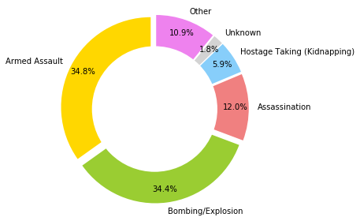

```python
fatal = {}
types = {}
total_killed = 0.0
total = 0.0
for index, row in df.iterrows():
    at = row['AttackType']
    total +=1
    if at in types:
          types[at] +=1
    else:
          types[at] = 1
    if row['Killed'] == 1:
        total_killed+=1
        if at in fatal:
              fatal[at] +=1
        else:
              fatal[at] = 1

for k,v in types.items():
    types[k] = (v/total)

for k,v in fatal.items():
    fatal[k] = (v/total_killed)
other = types["Facility/Infrastructure Attack"] + types["Hostage Taking (Barricade Incident)"] + types["Unarmed Assault"] + types["Hijacking"]

del types["Facility/Infrastructure Attack"]
del types["Hostage Taking (Barricade Incident)"]
del types["Unarmed Assault"]
del types["Hijacking"]

types["Other"] = other

#typetarget = {'Attack': df['TargetType'].values(), }

# Data to plot
labels = types.keys()
sizes = types.values()
colors = ['gold', 'yellowgreen', 'lightcoral', 'lightskyblue', 'lightgrey', 'violet']
explode = (0.05,0.05, 0.05,0.05,0.05,0.05)
# Plot
fig1, ax1 = plt.subplots()

plt.pie(sizes, colors = colors, labels=labels, autopct='%1.1f%%', startangle=90, pctdistance=0.85, explode = explode)
#draw circle
centre_circle = plt.Circle((0,0),0.70,fc='white')
fig = plt.gcf()
fig.gca().add_artist(centre_circle)
# Equal aspect ratio ensures that pie is drawn as a circle
ax1.axis('equal')
plt.tight_layout()
plt.show()
```

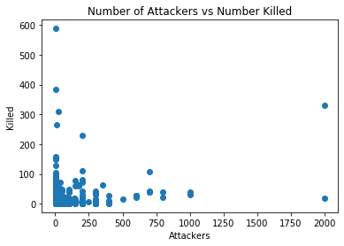

```python
#Create a new data frame only focusing on attacks where there was at least one fatality
killed = df[df.NumberKilled != 0]
#Create a scatter plot showing the number of attackers versus the number of victims killed
plt.scatter(killed["NumberAttackers"], killed["NumberKilled"])
plt.title("Number of Attackers vs Number Killed")
plt.xlabel("Attackers")
plt.ylabel("Killed")
```

There are several outlier attacks though and this is important to remember in any future data exploration because these few attacks with a very large number of fatalities may skew the data high. Because of a few large outliers and the large number of data points in the dataset it becomes difficult to see any trends that might be occurring in the 0-100 fatality range and the 0-50 attacker range. Additionally, we will get rid of all the 0 fatality events to focus on a correlation between the number of fatalities and number of attackers. To do this we will create a new dataframe only containing events with less than 50 fatalities and less than 50 attackers.

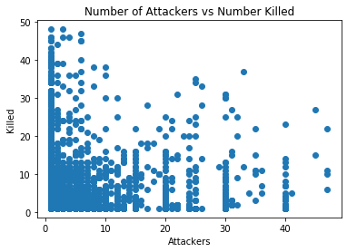

```python
#Create a new data frame only focusing on attacks where there was at least one fatality, the number killed was less than 50, and the number of attackers was less than 50
killed = df[df.NumberKilled != 0]
killed = killed[killed.NumberKilled <50]
killed = killed[killed.NumberAttackers < 50]
plt.scatter(killed["NumberAttackers"], killed["NumberKilled"])
plt.title("Number of Attackers vs Number Killed")
plt.xlabel("Attackers")
plt.ylabel("Killed")
```

Unfortunately this does not show an immediate clear line of regression, but we do notice that there appears to be a clustering of data around 40, 30, 25, 20, 15 attackers. This is possibly because a weakness in the dataset and a weakness in data collection. In terrorist attacks it is difficult to determine the exact number of assailants involved so media and law enforcement are often forced to estimate, leading to a disproportionate amount of data clustered around those values. We don’t see the same effect when considering the number of fatalities because victims are often left behind and law enforcement officials can get an exact count.

```python
#Here, we sort the data by region and sum up the statistics for each terrorist attack.
df["Count"] = 1
region = df.groupby('RegionCode', as_index= False).sum()
```

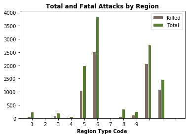

|  | Code | Region |
| --- | --- | --- |
| 0 | 1 | North America |
| 1 | 2 | Central America & Caribbean |
| 2 | 3 | South America |
| 3 | 4 | East Asia |
| 4 | 5 | Southeast Asia |
| 5 | 6 | South Asia |
| 6 | 7 | Central Asia |
| 7 | 8 | Western Europe |
| 8 | 9 | Eastern Europe |
| 9 | 10 | Middle East & North Africa |
| 10 | 11 | Sub-Saharan Africa |
| 11 | 12 | Australasia & Oceania |

```python
import numpy as np

# set width of bar
barWidth = 0.25

# set height of bar
killed = region['Killed'].values
total = region['Count'].values

# Set position of bar on X axis
r1 = np.arange(len(killed))
r2 = [x + barWidth for x in r1]

# Make the plot
plt.bar(r1, killed, color='#7f6d5f', width=barWidth, edgecolor='white', label='Killed')
plt.bar(r2, total, color='#557f2d', width=barWidth, edgecolor='white', label='Total')

# Add xticks on the middle of the group bars
plt.xlabel('Region Type Code', fontweight='bold')
plt.title('Total and Fatal Attacks by Region', fontweight='bold')
plt.xticks([r + barWidth for r in range(len(killed))], [1, 2, 3, 4, 5, 6, 7, 8, 9])

# Create legend & Show graphic
plt.legend()
plt.show()

regionCodes = {"Code":[1, 2, 3, 4, 5, 6, 7, 8, 9, 10, 11, 12], "Region":['North America', ' Central America & Caribbean', 'South America', 'East Asia', 'Southeast Asia', 'South Asia', 'Central Asia', 'Western Europe', 'Eastern Europe', 'Middle East & North Africa', ' Sub-Saharan Africa', 'Australasia & Oceania']}
atcodes = pd.DataFrame(regionCodes)
atcodes
```

Here we create a bar graph showing the total number of attacks of each attack type compared to the number of fatal attacks. Viewing them side by side allows us to see that certain attack types are much more common, and also that some attack types result in a significantly higher likelihood of fatalities.

```python
df["Count"] = 1
attack = df.groupby('AttackTypeCode', as_index= False).sum()
```

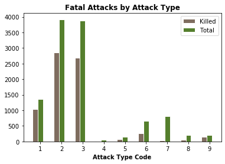

|  | Code | Attack Type |
| --- | --- | --- |
| 0 | 1 | Assasinated |
| 1 | 2 | Armed Assault |
| 2 | 3 | Bombing/Explosion |
| 3 | 4 | Hijacking |
| 4 | 5 | Hostage (Barricade) |
| 5 | 6 | Hostage (Kidnapping) |
| 6 | 7 | Infrastructure Attack |
| 7 | 8 | Unarmed Assault |
| 8 | 9 | Unknown |

```python
# set width of bar
barWidth = 0.25

# set height of bar
total = attack['Count'].values
killed = attack['Killed'].values

# Set position of bar on X axis
r1 = np.arange(len(killed))
r2 = [x + barWidth for x in r1]

# Make the plot
plt.bar(r1, killed, color='#7f6d5f', width=barWidth, edgecolor='white', label='Killed')
plt.bar(r2, total, color='#557f2d', width=barWidth, edgecolor='white', label='Total')

# Add xticks on the middle of the group bars
plt.xlabel('Attack Type Code', fontweight='bold')
plt.title('Fatal Attacks by Attack Type', fontweight='bold')
plt.xticks([r + barWidth for r in range(len(killed))], [1, 2, 3, 4, 5, 6, 7, 8, 9])

# Create legend & Show graphic
plt.legend()
plt.show()

attackTypes = {"Code": [1, 2, 3, 4, 5, 6, 7, 8, 9], "Attack Type": ['Assasinated', 'Armed Assault', 'Bombing/Explosion', 'Hijacking', 'Hostage (Barricade)', 'Hostage (Kidnapping)', 'Infrastructure Attack', 'Unarmed Assault', 'Unknown']}
atcodes = pd.DataFrame(attackTypes)
atcodes
```

```
Y = 0.033902551035955554x + -65.1911429660109
```

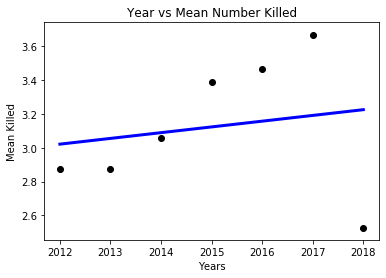

```python
df["Count"] = 1
mean = df.groupby('Year', as_index= False).mean()
sum = df.groupby('Year', as_index= False).sum()


from sklearn.linear_model import LinearRegression
# Dict = {"2012":0, "2013":0, "2014":0, "2015":0, "2016":0, "2017":0, "2018":0}
# for index, row in df.iterrows():
#   Dict[row[Year]] += row[NumberKilled]

x = mean["Year"].values.reshape(-1, 1)
y = mean["NumberKilled"].values.reshape(-1,1)
reg = LinearRegression()
reg.fit(x, y)

intercept = reg.intercept_
slope = reg.coef_
print ("Y = " + str(slope[0][0]) + "x + " + str(intercept[0]))

x = mean["Year"].values
y = mean["NumberKilled"].values
plt.scatter(x, y, color='black')
reg = LinearRegression()
reg.fit(x.reshape(-1,1), y.reshape(-1,1))
plt.plot(x, reg.predict(x.reshape(-1,1)), color='blue', linewidth=3)
plt.title("Year vs Mean Number Killed")
plt.xlabel("Years")
plt.ylabel("Mean Killed")
plt.show()
```

```
Y = 47.35714285714284x + -90331.21428571426
```

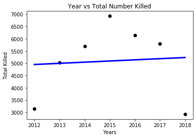

```python
x = sum["Year"].values.reshape(-1, 1)
y = sum["NumberKilled"].values.reshape(-1,1)
reg = LinearRegression()
reg.fit(x, y)

intercept = reg.intercept_
slope = reg.coef_
print ("Y = " + str(slope[0][0]) + "x + " + str(intercept[0]))

x = sum["Year"].values
y = sum["NumberKilled"].values
plt.scatter(x, y, color='black')
reg = LinearRegression()
reg.fit(x.reshape(-1,1), y.reshape(-1,1))
plt.plot(x, reg.predict(x.reshape(-1,1)), color='blue', linewidth=3)
plt.title("Year vs Total Number Killed")
plt.xlabel("Years")
plt.ylabel("Total Killed")
plt.show()
```

We can see a slight upwards trend, but we notice that 2018 appears to be an outlier. This is probably because the GTD team is in the process of entering data from 2018 into the database. Because 2018 is skewing the data, we decided to remove it.

```
Y = 508.8571428571431x + -1019638.3809523814
```

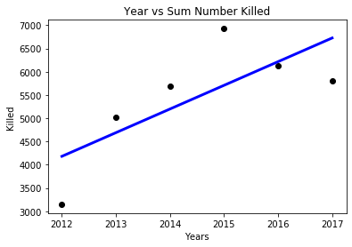

```python
sum = sum[sum.Year != 2018]

x = sum["Year"].values.reshape(-1, 1)
y = sum["NumberKilled"].values.reshape(-1,1)
reg = LinearRegression()
reg.fit(x, y)

intercept = reg.intercept_
slope = reg.coef_
print ("Y = " + str(slope[0][0]) + "x + " + str(intercept[0]))

x = sum["Year"].values
y = sum["NumberKilled"].values
plt.scatter(x, y, color='black')
reg = LinearRegression()
reg.fit(x.reshape(-1,1), y.reshape(-1,1))
plt.plot(x, reg.predict(x.reshape(-1,1)), color='blue', linewidth=3)
plt.title("Year vs Sum Number Killed")
plt.xlabel("Years")
plt.ylabel("Killed")
plt.show()
```

```
Y = 0.1730440740801512x + -345.37578986933954
```

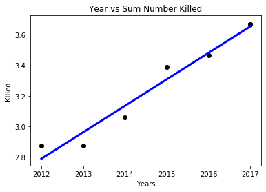

```python
mean = mean[mean.Year != 2018]

x = mean["Year"].values.reshape(-1, 1)
y = mean["NumberKilled"].values.reshape(-1,1)
reg = LinearRegression()
reg.fit(x, y)

intercept = reg.intercept_
slope = reg.coef_
print ("Y = " + str(slope[0][0]) + "x + " + str(intercept[0]))

x = mean["Year"].values
y = mean["NumberKilled"].values
plt.scatter(x, y, color='black')
reg = LinearRegression()
reg.fit(x.reshape(-1,1), y.reshape(-1,1))
plt.plot(x, reg.predict(x.reshape(-1,1)), color='blue', linewidth=3)
plt.title("Year vs Sum Number Killed")
plt.xlabel("Years")
plt.ylabel("Killed")
plt.show()
```

Once the 2018 data was removed, we see a strong upwards trend in casualties over the years. This can be explained through both geopolitics, increased worldwide reporting of terrorist attacks, and increased ability to capture a larger number of terrorist attacks through using the internet and data scraping techniques.

Here we do a chi-squared test to check for a relationship between suicide attacks and attacks with fatalities. Because suicide attacks mean that an attacker kills without regard to their own life, we hypothesize that suicide attacks are more likely to have fatalities than non-suicide attacks. In the example of a suicide bomber, intending to sacrifice oneself in a terrorist bombing means the attacker can choose in the moment where to set off the bomb to cause the most damage, making suicide attacks more likely to result in deaths. To do a chi-squared test we start with the null hypothesis that there is no difference in likelihood between each of the four sections, non-suicide non-fatal, suicide fatal, suicide non-fatal, and non-suicide fatal, meaning each should happen a roughly equal number of times. Our critical value is .95 meaning we can reject the null hypothesis with 95% certainty if the p-value is less than .05. The returned p-value is less than .05 so we reject the null hypothesis, meaning the variable Suicide and Killed are dependent and we should include suicide in our machine learning as a variable that influences whether an attack is fatal.

```python
from scipy.stats import chisquare
from scipy.stats import chi2_contingency
from scipy.stats import chi2


#Create a DataFrame with only the relevant columns
suicide_frame = df[['Suicide', 'Killed']]
suicide_frame.describe()
#Create a crosstab to give us a better idea of what the data looks like
data_crosstab = pd.crosstab(df['Suicide'],
                            df['Killed'],
                               margins = False)


print(data_crosstab)

stat, p, dof, expected = chi2_contingency(data_crosstab)
prob = 0.95
critical = chi2.ppf(prob, dof)
print('probability=%.3f, critical=%.3f, stat=%.3f' % (prob, critical, stat))
if abs(stat) >= critical:
	print('Dependent (reject H0)')
else:
	print('Independent (fail to reject H0)')
# interpret p-value
alpha = 1.0 - prob
print('significance=%.3f, p=%.3f' % (alpha, p))
if p <= alpha:
	print('Dependent (reject H0)')
else:
	print('Independent (fail to reject H0)')
```

```
Killed      0     1
Suicide
0        3973  4769
1         138  2378
probability=0.950, critical=3.841, stat=1344.180
Dependent (reject H0)
significance=0.050, p=0.000
Dependent (reject H0)
```

After exploring many of the variables in depth, we have a clearer picture of which variables affect fatality, meaning we want to include them as features in our machine learning.

## **Predicting Fatality**

We are going to use the random forest method to predict if an attack will be fatal or not. Click [here](https://towardsdatascience.com/random-forest-in-python-24d0893d51c0) for a detailed tutorial of this process. First we need to make sure there are only numerical variables. This creates a data frame that looks like this:

```python
machine_tidy = df[['Year', 'RegionCode', 'AttackTypeCode', 'Individual', 'NumberAttackers', 'WeaponTypeCode', 'Suicide', 'PropertyDamage', 'HostageKidnapping', "Killed"]]

machine_tidy
```

|  | Year | RegionCode | AttackTypeCode | Individual | NumberAttackers | WeaponTypeCode | Suicide | PropertyDamage | HostageKidnapping | Killed |
| --- | --- | --- | --- | --- | --- | --- | --- | --- | --- | --- |
| 16 | 2012 | 1 | 7 | 1 | 1 | 8 | 0 | 1 | 0 | 0 |
| 18 | 2012 | 6 | 2 | 0 | 2 | 5 | 0 | 1 | 0 | 1 |
| 19 | 2012 | 6 | 3 | 0 | 2 | 6 | 0 | 1 | 0 | 0 |
| 20 | 2012 | 6 | 3 | 0 | 2 | 6 | 1 | 0 | 0 | 0 |
| 26 | 2012 | 6 | 3 | 0 | 2 | 6 | 0 | 0 | 0 | 1 |
| 27 | 2012 | 11 | 2 | 0 | 15 | 5 | 0 | 1 | 0 | 1 |
| 41 | 2012 | 11 | 2 | 0 | 15 | 6 | 0 | 1 | 0 | 1 |
| 44 | 2012 | 6 | 3 | 0 | 1 | 6 | 1 | 1 | 0 | 1 |
| 45 | 2012 | 6 | 3 | 0 | 1 | 6 | 1 | 1 | 0 | 1 |
| 67 | 2012 | 5 | 2 | 0 | 50 | 6 | 0 | 0 | 0 | 1 |
| 74 | 2012 | 9 | 3 | 0 | 2 | 6 | 0 | 0 | 0 | 0 |
| 76 | 2012 | 11 | 2 | 0 | 7 | 6 | 0 | 1 | 0 | 0 |
| 80 | 2012 | 1 | 7 | 1 | 1 | 8 | 0 | 1 | 0 | 0 |
| 87 | 2012 | 10 | 2 | 0 | 5 | 5 | 0 | 1 | 0 | 1 |
| 111 | 2012 | 10 | 3 | 0 | 1 | 6 | 1 | 0 | 0 | 1 |
| 117 | 2012 | 6 | 1 | 0 | 4 | 5 | 0 | 1 | 0 | 1 |
| 118 | 2012 | 6 | 2 | 0 | 2 | 5 | 0 | 1 | 0 | 1 |
| 122 | 2012 | 5 | 2 | 0 | 1 | 5 | 0 | 0 | 0 | 1 |
| 127 | 2012 | 5 | 2 | 0 | 2 | 5 | 0 | 1 | 0 | 1 |
| 134 | 2012 | 5 | 2 | 0 | 30 | 5 | 0 | 1 | 0 | 1 |
| 157 | 2012 | 11 | 2 | 0 | 3 | 5 | 0 | 1 | 0 | 1 |
| 163 | 2012 | 6 | 2 | 0 | 1 | 5 | 0 | 1 | 0 | 1 |
| 170 | 2012 | 6 | 2 | 0 | 6 | 6 | 0 | 1 | 0 | 1 |
| 171 | 2012 | 6 | 2 | 0 | 6 | 5 | 0 | 1 | 0 | 1 |
| 172 | 2012 | 6 | 3 | 0 | 6 | 6 | 0 | 1 | 0 | 0 |
| 173 | 2012 | 10 | 3 | 0 | 1 | 6 | 1 | 1 | 0 | 1 |
| 178 | 2012 | 10 | 3 | 0 | 2 | 6 | 0 | 0 | 0 | 1 |
| 192 | 2012 | 6 | 3 | 0 | 1 | 6 | 1 | 0 | 0 | 1 |
| 196 | 2012 | 6 | 2 | 0 | 1 | 5 | 0 | 0 | 0 | 1 |
| 213 | 2012 | 1 | 2 | 1 | 1 | 5 | 0 | 0 | 0 | 0 |
| ... | ... | ... | ... | ... | ... | ... | ... | ... | ... | ... |
| 86436 | 2018 | 11 | 3 | 0 | 2 | 6 | 1 | 1 | 0 | 1 |
| 86439 | 2018 | 5 | 9 | 0 | 30 | 13 | 0 | 0 | 0 | 1 |
| 86443 | 2018 | 6 | 3 | 0 | 1 | 6 | 1 | 0 | 0 | 1 |
| 86452 | 2018 | 5 | 1 | 0 | 3 | 5 | 0 | 0 | 0 | 1 |
| 86456 | 2018 | 5 | 5 | 0 | 6 | 5 | 0 | 1 | 1 | 0 |
| 86461 | 2018 | 8 | 7 | 1 | 1 | 11 | 0 | 1 | 0 | 0 |
| 86463 | 2018 | 5 | 6 | 0 | 30 | 5 | 0 | 1 | 1 | 1 |
| 86470 | 2018 | 6 | 2 | 0 | 10 | 9 | 0 | 0 | 0 | 0 |
| 86498 | 2018 | 6 | 5 | 0 | 6 | 6 | 1 | 1 | 1 | 1 |
| 86499 | 2018 | 11 | 3 | 0 | 1 | 6 | 0 | 0 | 0 | 0 |
| 86500 | 2018 | 10 | 3 | 0 | 3 | 6 | 1 | 1 | 0 | 1 |
| 86527 | 2018 | 6 | 3 | 0 | 5 | 6 | 0 | 0 | 0 | 1 |
| 86574 | 2018 | 5 | 2 | 0 | 1 | 5 | 0 | 0 | 0 | 0 |
| 86584 | 2018 | 6 | 2 | 0 | 3 | 5 | 0 | 0 | 0 | 1 |
| 86587 | 2018 | 5 | 1 | 0 | 2 | 5 | 0 | 0 | 0 | 1 |
| 86596 | 2018 | 5 | 1 | 0 | 2 | 5 | 0 | 0 | 0 | 0 |
| 86614 | 2018 | 6 | 7 | 0 | 25 | 8 | 0 | 1 | 0 | 0 |
| 86615 | 2018 | 6 | 3 | 0 | 25 | 6 | 0 | 1 | 0 | 0 |
| 86616 | 2018 | 6 | 7 | 0 | 25 | 8 | 0 | 1 | 0 | 0 |
| 86622 | 2018 | 5 | 2 | 0 | 5 | 5 | 0 | 0 | 0 | 1 |
| 86625 | 2018 | 10 | 2 | 0 | 1 | 5 | 0 | 0 | 0 | 1 |
| 86626 | 2018 | 11 | 9 | 0 | 6 | 13 | 0 | 0 | 0 | 1 |
| 86630 | 2018 | 6 | 7 | 0 | 2 | 5 | 0 | 1 | 0 | 0 |
| 86632 | 2018 | 6 | 2 | 0 | 2 | 5 | 0 | 0 | 0 | 0 |
| 86633 | 2018 | 1 | 1 | 0 | 2 | 5 | 0 | 0 | 0 | 1 |
| 86634 | 2018 | 5 | 6 | 0 | 12 | 9 | 0 | 0 | 1 | 1 |
| 86649 | 2018 | 8 | 2 | 1 | 1 | 9 | 0 | 0 | 0 | 0 |
| 86654 | 2018 | 10 | 1 | 0 | 3 | 5 | 0 | 1 | 0 | 0 |
| 86655 | 2018 | 11 | 1 | 0 | 20 | 5 | 0 | 0 | 0 | 0 |
| 86657 | 2018 | 5 | 2 | 0 | 12 | 6 | 0 | 0 | 0 | 0 |

11258 rows × 10 columns

Next we will decide what features we want to use to predict which target. We have already decided which features may have an affect on the deadliness of a terrorist event, and have decided we want our target (the outcome we are trying to predict) to be whether or not the attack causes fatalities.

```python
# Labels are the values we want to predict
labels = np.array(machine_tidy['Killed'])
# Remove the labels from the features
# axis 1 refers to the columns
machine_tidy= machine_tidy.drop('Killed', axis = 1)
# Saving feature names for later use
feature_list = list(machine_tidy.columns)
# Convert to numpy array
machine_tidy = np.array(machine_tidy)
```

Next we split the data into a testing and training set. This needs to be split up randomly for the machine to learn properly, it will not work if we train the set on just data from certain months, and then test it on different months.

```python
# Using Skicit-learn to split data into training and testing sets
from sklearn.model_selection import train_test_split
# Split the data into training and testing sets
train_features, test_features, train_labels, test_labels = train_test_split(machine_tidy, labels, test_size = 0.25, random_state = 13)
```

To check that everything is partitioned properly, print the shape of the data. It should look like this:

```python
print('Training Features Shape:', train_features.shape)
print('Training Labels Shape:', train_labels.shape)
print('Testing Features Shape:', test_features.shape)
print('Testing Labels Shape:', test_labels.shape)
```

```
Training Features Shape: (8443, 9)
Training Labels Shape: (8443,)
Testing Features Shape: (2815, 9)
Testing Labels Shape: (2815,)
```

Next we train the data. The number of trees can affect the models ability so play around with different numbers.

```python
# Import the model we are using
from sklearn.ensemble import RandomForestRegressor
# Instantiate model with 1000 decision trees
rf = RandomForestRegressor(n_estimators = 8000, random_state = 13)
# Train the model on training data
rf.fit(train_features, train_labels);
```

```python
# Use the forest's predict method on the test data
predictions = rf.predict(test_features)
# Calculate the absolute errors
errors = abs(predictions - test_labels)
# Print out the mean absolute error (mae)
print('Mean Absolute Error:', round(np.mean(errors), 2))
```

```
Mean Absolute Error: 0.27
```

```python
# Import tools needed for visualization
from sklearn.tree import export_graphviz
!pip install pydot
!pip install graphviz
# Pull out one tree from the forest
tree = rf.estimators_[5]
# Import tools needed for visualization
from sklearn.tree import export_graphviz
import pydot
# Pull out one tree from the forest
tree = rf.estimators_[5]
# Export the image to a dot file
export_graphviz(tree, out_file = 'tree.dot', feature_names = feature_list, rounded = True, precision = 1)
# Use dot file to create a graph
(graph, ) = pydot.graph_from_dot_file('tree.dot')
# Write graph to a png file
graph.write_png('tree.png')
```

```python
from IPython.display import Image
Image('tree.png')
```

[output not shown]

This shows which variables are most important. In our case, the type of attack was most influential to whether or not there were fatalities, followed by number of attackers and weapon type. The least important factors were whether or not the attacker was an individual lone wolf or associated with a group.

```python
# Get numerical feature importances
importances = list(rf.feature_importances_)
# List of tuples with variable and importance
feature_importances = [(feature, round(importance, 2)) for feature, importance in zip(feature_list, importances)]
# Sort the feature importances by most important first
feature_importances = sorted(feature_importances, key = lambda x: x[1], reverse = True)
# Print out the feature and importances
[print('Variable: {:20} Importance: {}'.format(*pair)) for pair in feature_importances];
```

```
Variable: AttackTypeCode       Importance: 0.27
Variable: NumberAttackers      Importance: 0.17
Variable: WeaponTypeCode       Importance: 0.15
Variable: Year                 Importance: 0.13
Variable: RegionCode           Importance: 0.11
Variable: Suicide              Importance: 0.1
Variable: PropertyDamage       Importance: 0.03
Variable: Individual           Importance: 0.01
Variable: HostageKidnapping    Importance: 0.01
```

## **Conclusion**

Our prediction for whether or not an attack would be deadly could use some improvement, but it is a start. While variables like weapon type, attack type, whether it was a suicide attack, and the number of attackers do have some bearing on whether an attack will be fatal, there are many other factors at play. Additionally there are flaws in the data as a result of the dangerous environment terrorist attacks cause, and because in many regions were terrorism occurs institutions are weak, disorganized, and corrupt, and have difficulty obtaining accurate supports. Another weakness in the dataset is that countries may want to hide terrorism within their borders and fail to report it or even cover it up. Another potential variable that was included in the dataset but had too many unique identifiers for our purpose was the Group name variable. This could have significant impact onto the deadliness of attacks because different groups have different modus operandi and different training. Future work should include this variable as well. Although the nature of terrorism makes the GTD imperfect, it is still an incredible wealth of knowledge that can be used to improving lives worldwide. Future data science investigation into the topic could lead to new U.S. foreign policies or treatises of behavior abroad.